# Quality control

Thomas Amble Karlsen

2026-02-08

## 1 Loading libraries

```r
library(tidyverse)
library(patchwork)
```

## 2 Reading data and wrangling

Reading the MultiQC general statistics and wrangling to only keep input reads, reads that remained after quality filtering with `fastp`, reads that remained after complexity filtering with `BBDuk` and reads that remained after host removal with `Bowtie2` for each sample.

Also reading the Kraken2 results and summarising all mapped reads except for unmapped reads (Taxonomy ID = 0) to find total number of mapped reads.

Finally, combining the QC results with the Kraken2 classification results and the rarefied reads per sample.

```r
mqc <- read_delim("/Users/thomasamble/Downloads/Master/R_master/taxprofiler_multiQC/multiqc_general_stats.txt")

mqc_reads <- mqc %>%
  select(Sample, `fastqc_falco_pre_trimming-total_sequences`, `fastp-filtering_result_passed_filter_reads`, `samtools_stats_stats-raw_total_sequences`, `samtools_stats_stats-reads_mapped`) %>%
  rename(raw_reads = `fastqc_falco_pre_trimming-total_sequences`, # input to fastqc = raw_reads
         survived_fastp = `fastp-filtering_result_passed_filter_reads`, # passed fastp filtering
         survived_bbduk = `samtools_stats_stats-raw_total_sequences`, # bowtie2 input = bbduk output
         samtools_mapped = `samtools_stats_stats-reads_mapped`) %>% # reads mapped to host
  mutate(survived_bowtie2 = survived_bbduk - samtools_mapped) %>% # bbduk output - host reads
  select(-samtools_mapped) %>%
  mutate(across(c(3:5), ~.x/2)) %>% # Dividing by 2 on columns where R1 and R2 is merged
  filter(str_detect(Sample, "NovaSeq_2025")) %>% # removing classifier rows
  mutate(basename = str_remove(Sample, "_raw_[12]$")) %>%
  group_by(basename) %>%
  summarise(Sample = first(basename), # merging all rows because MultiQC table is ugly
            raw_reads = first(raw_reads[!is.na(raw_reads)]),
            survived_fastp = first(survived_fastp[!is.na(survived_fastp)]),
            survived_bbduk = first(survived_bbduk[!is.na(survived_bbduk)]),
            survived_bowtie2 = first(survived_bowtie2[!is.na(survived_bowtie2)])) %>%
  ungroup() %>%
  select(-basename) %>%
  filter(!if_all(-Sample, is.na)) %>%
  mutate(Sample = str_remove(Sample, "_NovaSeq_2025_L00[45]$"),
         Sample = str_remove(Sample, "\\d+-")) %>%
  group_by(Sample) %>%
  summarise(across(everything(), sum)) %>%
  ungroup() %>%
  mutate(across(where(is.numeric), ~ .x * 1e6)) %>%
  rename(sample = Sample)

kraken_classified_reads <- read_tsv("/Users/thomasamble/Downloads/Master/R_master/taxprofiler_taxpasta/kraken2_PlusPFP_14.07.2025.tsv") %>%
  filter(taxonomy_id != 0) %>%
  pivot_longer(cols = -taxonomy_id,
               names_to = "sample",
               values_to = "mapped_reads") %>%
  group_by(sample) %>%
  summarise(kraken_mapped_reads = sum(mapped_reads)) %>%
  ungroup() %>%
  mutate(sample = str_remove(sample, "_PlusPFP_14.07.2025.kraken2.kraken2.report"),
         sample = str_remove(sample, "^\\d+-"))

full_read_life <- mqc_reads %>%
  left_join(kraken_classified_reads, by = "sample") %>%
  mutate(rarefied_reads = 9808431) # hard coded, might want to fix later so it is more tidy
```

## 3 Plotting fastp, BBDuk, Bowtie2 effect

Plotting the fraction of reads removed during the three QC steps per sample, alongside the total number of reads removed during QC per sample. Also performing a sanity check to see how many reads were removed during host removal for the Microbiota control sample.

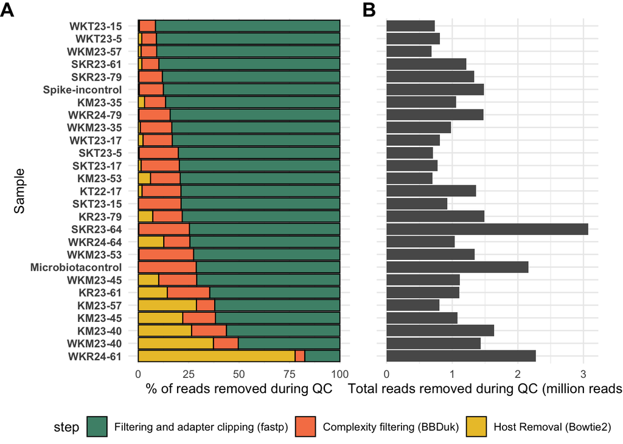

```r
qcp1 <- full_read_life %>%
  mutate(removed_fastp = raw_reads - survived_fastp,
         removed_bbduk = survived_fastp -survived_bbduk,
         removed_bowtie2 = survived_bbduk - survived_bowtie2,
         removed_total = removed_fastp + removed_bbduk + removed_bowtie2,
         pct_removed_fastp = removed_fastp/removed_total * 100,
         pct_removed_bbduk = removed_bbduk/removed_total * 100,
         pct_removed_bowtie2 = removed_bowtie2/removed_total * 100,
         sample = reorder(sample, pct_removed_fastp)) %>%
  select(sample, pct_removed_fastp, pct_removed_bbduk, pct_removed_bowtie2) %>%
  pivot_longer(-sample,
               names_to = "step",
               values_to = "percent") %>%
  mutate(step = factor(step,
                       levels = c("pct_removed_fastp",
                                  "pct_removed_bbduk",
                                  "pct_removed_bowtie2"),
                       labels = c("Filtering and adapter clipping (fastp)",
                                  "Complexity filtering (BBDuk)",
                                  "Host Removal (Bowtie2)"))) %>%
  ggplot(aes(x = sample,
             y = percent,
             fill = step)) +
  geom_col(color = "black", linewidth = 0.4) +
  coord_flip() +
  scale_fill_manual(values = c("#4D9078", "#F78154", "#EBC334")) +
  labs(y = "% of reads removed during QC",
       x = "Sample") +
    theme_minimal() +
  theme(axis.text.y = element_text(face = "bold"),
        legend.position = "top",
        legend.box.margin = margin(0, 100))


qcp2 <- full_read_life %>%
  mutate(removed_fastp = raw_reads - survived_fastp,
         removed_bbduk = survived_fastp -survived_bbduk,
         removed_bowtie2 = survived_bbduk - survived_bowtie2,
         removed_total = removed_fastp + removed_bbduk + removed_bowtie2,
         pct_removed_fastp = removed_fastp/removed_total * 100,
         Sample = reorder(sample, pct_removed_fastp)) %>%
  select(Sample, removed_total, pct_removed_fastp) %>%
  ggplot(aes(x = Sample,
             y = removed_total / 1e6)) +
  geom_col(linewidth = 0.4) +
  coord_flip() +
  labs(y = "Total reads removed during QC (million reads)") +
  theme_minimal() +
  theme(axis.text.y  = element_blank(),
        axis.title.y = element_blank())

qcp1 + qcp2 +
  plot_layout(guides = "collect") +
  plot_annotation(tag_levels = "A") &
  theme(legend.position = "bottom", # looks ugly with the tag_levels when = "top"
        plot.margin = margin(0,10,0,0),
        legend.box.margin = margin(0,50,0,0),
        plot.tag = element_text(size = 16, face = "bold"))
```

```r
# sanity check to see how many reads were removed for the microbiotacontrol-sample from bowtie2 (expecting low)
full_read_life %>%
  filter(sample == "Microbiotacontrol") %>%
  summarise(diff = survived_bbduk - survived_bowtie2)
```

```
## # A tibble: 1 × 1
##    diff
##   <dbl>
## 1  34.0
```

## 4 Plotting read utilization from raw reads

Plotting the number of reads remaining at each step (raw reads, reads that remained after trimming/filtering with fastp, reads that remained after filtering with BBDuk, remaining reads after host removal, number of reads classified by Kraken2, and number of reads all samples were rarefied to)

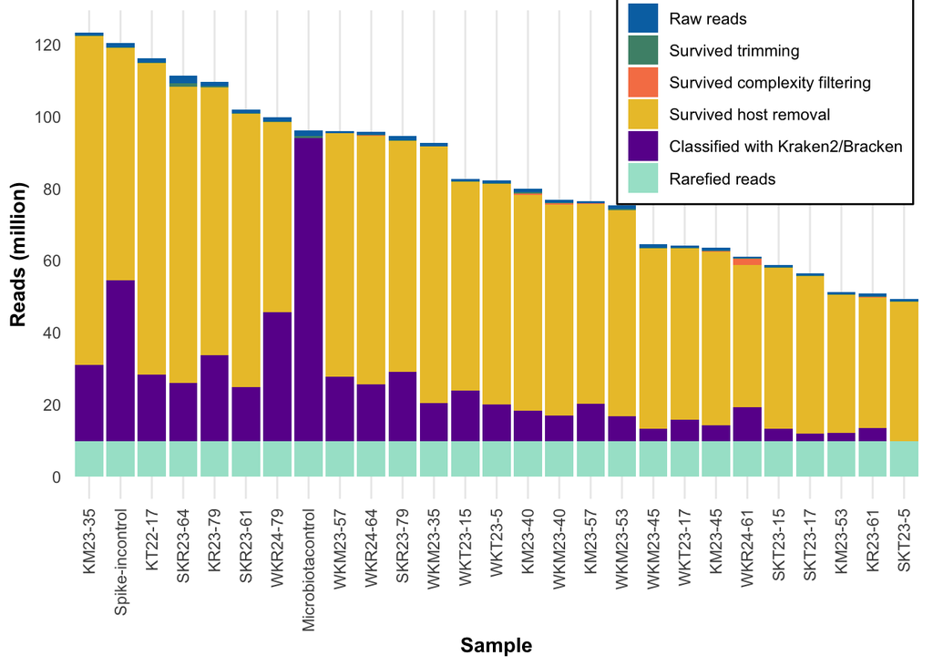

```r
full_read_life %>%
  mutate(sample = fct_reorder(sample, raw_reads, .desc = T)) %>%
  pivot_longer(-sample,
               names_to = "Stage",
               values_to = "Reads") %>%
  mutate(Stage = factor(Stage, levels = c("raw_reads", "survived_fastp", "survived_bbduk", "survived_bowtie2", "kraken_mapped_reads", "rarefied_reads"))) %>%
  ggplot(aes(x = sample,
             y = Reads / 1e6,
             fill = Stage)) +
  geom_col(position = "identity") +
  scale_fill_manual(values = c(raw_reads = "#0072B2",
                               survived_fastp = "#4D9078",
                               survived_bbduk = "#F78154",
                               survived_bowtie2 = "#EBC334",
                               kraken_mapped_reads = "#6A1B9A",
                               rarefied_reads = "#A6E3D0"),
                  labels = c("Raw reads", "Survived trimming", "Survived complexity filtering", "Survived host removal", "Classified with Kraken2/Bracken", "Rarefied reads")) +
  scale_y_continuous(breaks = seq(0, 140, by = 20)) +
  theme_minimal() +
  theme(axis.text.x = element_text(angle = 90, vjust = 0.5, hjust = 1, margin = margin(t = -9)),
        axis.ticks.x = element_blank(),
        legend.title = element_blank(),
        legend.position = "inside",
        legend.position.inside = c(0.815,0.82),
        legend.background = element_rect(fill = "white"),
        axis.title = element_text(face = "bold"),
        panel.grid.major.y = element_blank(),
        panel.grid.minor = element_blank()) +
  labs(x = "Sample", y = "Reads (million)")
```